# Bechdel

Anna Smyrnova

August 21, 2019

# Part 1: Data setup

You have a dataset called “Bechdel.xlsx” in Excel format. Import it into R and prepare the dataset for analysis.

```r
library(readxl)
bechdel <- read_excel("bechdel.xlsx", col_types = c("numeric",
     "text", "numeric", "numeric", "numeric",
     "text", "numeric", "numeric", "numeric",
     "text", "skip", "skip"), skip = 1)

bechdel$year<-as.integer(bechdel$year)
head(bechdel)
```

```
## # A tibble: 6 x 10
##    year imdb  budget domgross intgross code  budget_2013 domgross_2013
##   <int> <chr>  <dbl>    <dbl>    <dbl> <chr>       <dbl>         <dbl>
## 1  1974 tt00~ 1.30e7 57300000   5.73e7 1974~    61408439     270669505
## 2  1982 tt00~ 1.07e7 74706019   1.22e8 1982~    25821968     180285645
## 3  2008 tt08~ 1.50e7  2203641   6.38e6 2008~    16233845       2384904
## 4  2011 tt16~ 1.20e7 16311571   2.28e7 2011~    12428289      16893744
## 5  2000 tt01~ 2.60e7 45506619   7.58e7 2000~    35175618      61566286
## 6  2009 tt12~ 2.00e7 14363397   1.91e7 2009~    21714632      15594794
## # ... with 2 more variables: intgross_2013 <dbl>, binary <chr>
```

```r
str(bechdel)
```

```
## Classes 'tbl_df', 'tbl' and 'data.frame':    1500 obs. of  10 variables:
##  $ year         : int  1974 1982 2008 2011 2000 2009 2007 2009 2005 2002 ...
##  $ imdb         : chr  "tt0071562" "tt0084516" "tt0800241" "tt1625346" ...
##  $ budget       : num  1.30e+07 1.07e+07 1.50e+07 1.20e+07 2.60e+07 2.00e+07 3.00e+08 8.00e+07 2.00e+06 1.60e+07 ...
##  $ domgross     : num  57300000 74706019 2203641 16311571 45506619 ...
##  $ intgross     : num  5.73e+07 1.22e+08 6.38e+06 2.28e+07 7.58e+07 ...
##  $ code         : chr  "1974PASS" "1982PASS" "2008PASS" "2011PASS" ...
##  $ budget_2013  : num  61408439 25821968 16233845 12428289 35175618 ...
##  $ domgross_2013: num  2.71e+08 1.80e+08 2.38e+06 1.69e+07 6.16e+07 ...
##  $ intgross_2013: num  2.71e+08 2.94e+08 6.90e+06 2.36e+07 1.03e+08 ...
##  $ binary       : chr  "PASS" "PASS" "PASS" "PASS" ...
```

### Labels

```r
label <- read_excel("bechdel.xlsx", sheet = "bechdel",
     range = "A1:J1", col_names = FALSE)
## to characters
label = as.character(label[1,])

## assign labels
set_variable_labels(bechdel, label)
```

```
## # A tibble: 1,500 x 10
##     year imdb  budget domgross intgross code  budget_2013 domgross_2013
##    <int> <chr>  <dbl>    <dbl>    <dbl> <chr>       <dbl>         <dbl>
##  1  1974 tt00~ 1.30e7   5.73e7   5.73e7 1974~    61408439     270669505
##  2  1982 tt00~ 1.07e7   7.47e7   1.22e8 1982~    25821968     180285645
##  3  2008 tt08~ 1.50e7   2.20e6   6.38e6 2008~    16233845       2384904
##  4  2011 tt16~ 1.20e7   1.63e7   2.28e7 2011~    12428289      16893744
##  5  2000 tt01~ 2.60e7   4.55e7   7.58e7 2000~    35175618      61566286
##  6  2009 tt12~ 2.00e7   1.44e7   1.91e7 2009~    21714632      15594794
##  7  2007 tt04~ 3.00e8   3.09e8   9.61e8 2007~   337063045     347647302
##  8  2009 tt08~ 8.00e7   1.97e7   5.35e7 2009~    86858528      21363903
##  9  2005 tt03~ 2.00e6   2.07e6   2.08e6 2005~     2386066       2472734
## 10  2002 tt02~ 1.60e7   1.64e7   2.17e7 2002~    20722867      21186244
## # ... with 1,490 more rows, and 2 more variables: intgross_2013 <dbl>,
## #   binary <chr>
```

```r
rm(label)
```

### Missing values

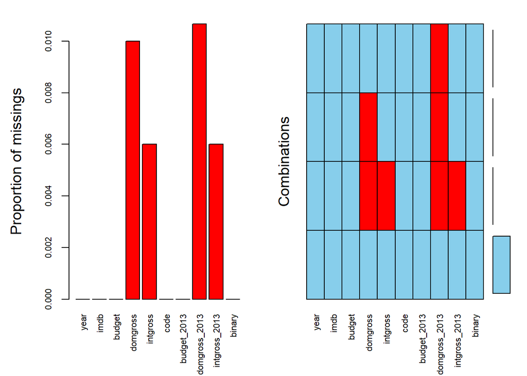

Missing data proportions and patterns

```r
#The visuals were created using the VIM package.
aggr(bechdel, cex.axis = 0.7)
```

```r
pander(summary(bechdel))
```

Table continues below

| year | imdb | budget | domgross |
| --- | --- | --- | --- |
| Min. :1970 | Length:1500 | Min. : 7000 | Min. : 0 |
| 1st Qu.:1999 | Class :character | 1st Qu.: 12000000 | 1st Qu.: 16235738 |
| Median :2005 | Mode :character | Median : 28000000 | Median : 42670410 |
| Mean :2003 | NA | Mean : 45189272 | Mean : 70393493 |
| 3rd Qu.:2009 | NA | 3rd Qu.: 61000000 | 3rd Qu.: 95020213 |
| Max. :2013 | NA | Max. :425000000 | Max. :760507625 |
| NA | NA | NA | NA’s :15 |

Table continues below

| intgross | code | budget_2013 | domgross_2013 |
| --- | --- | --- | --- |
| Min. :8.280e+02 | Length:1500 | Min. : 8632 | Min. :8.990e+02 |
| 1st Qu.:2.529e+07 | Class :character | 1st Qu.: 16023478 | 1st Qu.:2.022e+07 |
| Median :7.805e+07 | Mode :character | Median : 36843687 | Median :5.608e+07 |
| Mean :1.539e+08 | NA | Mean : 55866095 | Mean :9.719e+07 |
| 3rd Qu.:1.965e+08 | NA | 3rd Qu.: 81169688 | 3rd Qu.:1.255e+08 |
| Max. :2.784e+09 | NA | Max. :461435929 | Max. :1.772e+09 |
| NA’s :9 | NA | NA | NA’s :16 |

| intgross_2013 | binary |
| --- | --- |
| Min. :8.990e+02 | Length:1500 |
| 1st Qu.:3.183e+07 | Class :character |
| Median :9.856e+07 | Mode :character |
| Mean :2.028e+08 | NA |
| 3rd Qu.:2.459e+08 | NA |
| Max. :3.172e+09 | NA |
| NA’s :9 | NA |

Looks like there are no outliers/errors, all data looks quite reasonable (for example, Avatar had the budget of USD425,000,000 and worldwide gross of USD2,789,705,275 in 2009). The distribution of missing data indicates that 4 variables have missing data points, but proportion of missing values are very small, imputation will not be necessary, a complete case analysis will suffice.

```r
bechdel<-bechdel[complete.cases(bechdel), ]
```

# Part 2: Data analysis

1. Summarise the data using any descriptive statistics, inferential statistics, or visualisations that you deem appropriate. Address the following questions as well: – What percentage of movies passed the test, based on the binary definition?

```r
# What percentage of movies passed the test, based on the binary definition?
bechdel %>%
  group_by(binary) %>%
  summarise (number = n() ) %>%
  mutate(freq = number / sum(number)) %>% ungroup()
```

```
## # A tibble: 2 x 3
##   binary number  freq
##   <chr>   <int> <dbl>
## 1 FAIL      820 0.553
## 2 PASS      664 0.447
```

- How does the percentage of movies passing change over time?

```r
pct_year<- bechdel %>%
  group_by(year, binary) %>%
  summarise (number = n() ) %>%
  mutate(freq = number / sum(number)) %>% ungroup()

total_year<-bechdel %>%
  group_by(year)%>%
  summarise (total = n() ) %>% ungroup

pct_pass <- pct_year %>%
  dplyr::select(year, binary, number, freq) %>%
  full_join(total_year, by="year")

rm(pct_year, total_year)
```

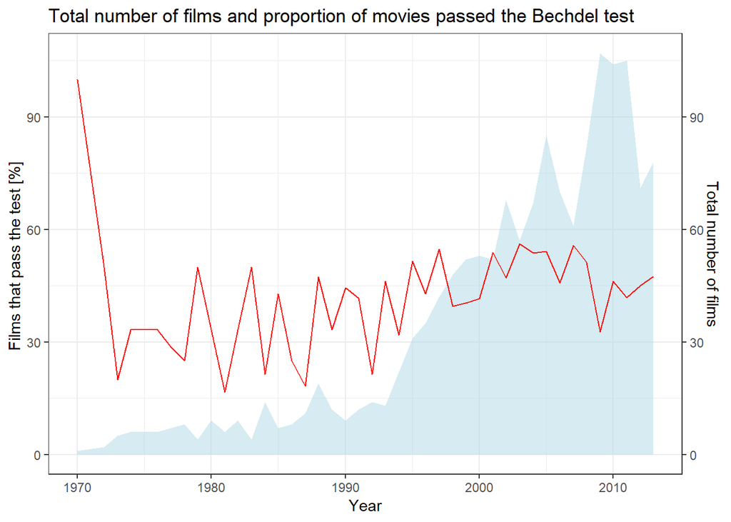

```r
figure1 <- pct_pass %>% dplyr::filter(binary=="PASS")

ggplot(figure1) +
geom_area( fill="lightblue", alpha=.5, aes(y = total, x=year)) +
geom_line( color="red", alpha=1, aes(y = freq*100, x=year)) +
ggtitle("Total number of films and proportion of movies passed the Bechdel test") +
scale_y_continuous(sec.axis = sec_axis(~., name = "Total number of films")) +
labs(y = "Films that pass the test [%] ", x = "Year") +
theme_bw()+
scale_x_continuous(breaks=seq(1970, 2013, 10))+
theme(legend.text = element_text(colour="blue", size=10, face="bold"))
```

As we use more data, the proportion of movies passed the Bechdel test tends to show less variation.

```r
#decade categories
bechdel$decade<-cut(bechdel$year, c(1969, 1980,1990,2000, 2014), right=FALSE)

bechdel$decade<-factor(bechdel$decade, labels = c("1970x", "1980x", "1990x", "2000x"))

decade_ds <- bechdel %>%
  group_by(decade, binary) %>%
  summarise (number = n() ) %>%
  mutate(freq = number / sum(number)) %>% ungroup()

pander(decade_ds)
```

| decade | binary | number | freq |
| --- | --- | --- | --- |
| 1970x | FAIL | 34 | 0.7234 |
| 1970x | PASS | 13 | 0.2766 |
| 1980x | FAIL | 67 | 0.6768 |
| 1980x | PASS | 32 | 0.3232 |
| 1990x | FAIL | 159 | 0.5719 |
| 1990x | PASS | 119 | 0.4281 |
| 2000x | FAIL | 560 | 0.5283 |
| 2000x | PASS | 500 | 0.4717 |

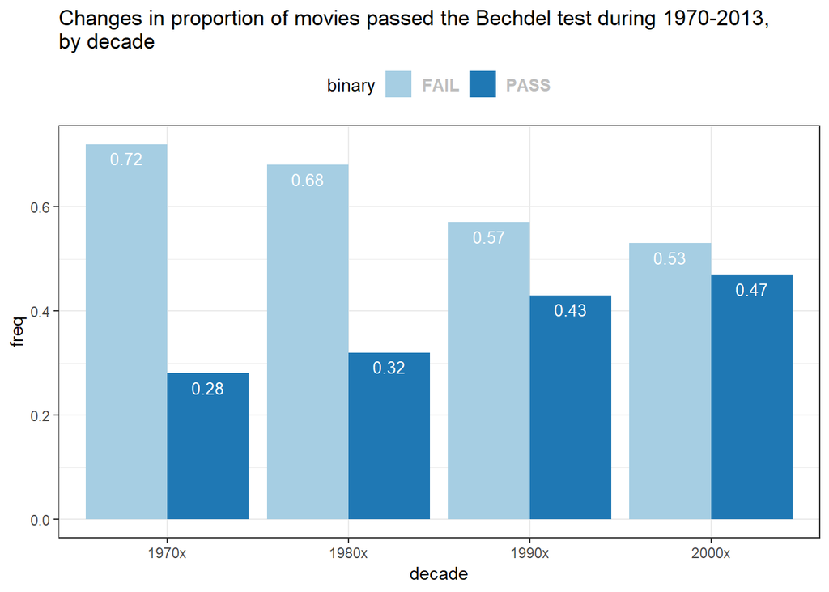

```r
# the overall tendency by decade
pct_decade<-  bechdel %>%
  group_by(decade, binary) %>%
  summarise (number = n() ) %>%
  mutate(freq = round(number / sum(number),2)) %>% ungroup()


ggplot(data=pct_decade, aes(x=decade, y=freq, fill=binary)) +
  geom_bar(stat="identity",position=position_dodge())+
geom_text(aes(label=freq), vjust=1.6, color="white",
            position = position_dodge(0.9), size=3.5)+
  scale_fill_brewer(palette="Paired")+
ggtitle("Changes in proportion of movies passed the Bechdel test during 1970-2013, \nby decade")+
  theme(legend.text = element_text(colour="grey", size=10, face="bold"))
```

```r
budget_year<-  bechdel %>%
  group_by(year, binary) %>%
  summarise (mean_budget=mean(budget_2013), mean_domgross=mean(domgross_2013), mean_intgross=mean(intgross_2013)) %>%
  mutate(roi=(mean_domgross+mean_intgross)/mean_budget, mean_total=mean_domgross+mean_intgross)
```

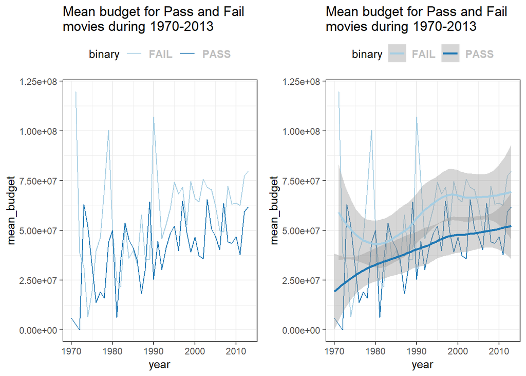

```r
p1<-ggplot(data=budget_year, aes(x=year, y=mean_budget, color=binary))+
  geom_line()+
  scale_color_brewer(palette="Paired")+
ggtitle("Mean budget for Pass and Fail \nmovies during 1970-2013")+
  theme(legend.text = element_text(colour="grey", size=10, face="bold"))

p2<-ggplot(data=budget_year, aes(x=year, y=mean_total, color=binary))+
  geom_line()+
  scale_color_brewer(palette="Paired")+
ggtitle("Mean gross (domestic + inter) for \nPass and Fail movies during 1970-2013")+
  theme(legend.text = element_text(colour="grey", size=10, face="bold"))

p3<-ggplot(data=budget_year, aes(x=year, y=roi, color=binary))+
  geom_line()+
  scale_color_brewer(palette="Paired")+
ggtitle(" ROI for Pass and Fail movies \nduring 1970-2013")+
  theme(legend.text = element_text(colour="grey", size=10, face="bold"))

p4<-ggplot(data=budget_year, aes(x=year, y=mean_budget, color=binary))+
  geom_line()+
  scale_color_brewer(palette="Paired")+
ggtitle("Mean budget for Pass and Fail \nmovies during 1970-2013")+
  geom_smooth(method = "loess") +
  theme(legend.text = element_text(colour="grey", size=10, face="bold"))

p5<-ggplot(data=budget_year, aes(x=year, y=mean_total, color=binary))+
  geom_line()+
  scale_color_brewer(palette="Paired")+
ggtitle("Mean gross (domestic + inter)for \nPass and Fail movies during 1970-2013")+
  geom_smooth(method = "loess") +
  theme(legend.text = element_text(colour="grey", size=10, face="bold"))

p6<-ggplot(data=budget_year, aes(x=year, y=roi, color=binary))+
  geom_line()+
  scale_color_brewer(palette="Paired")+
ggtitle(" ROI for Pass and Fail movies \nduring 1970-2013")+
  geom_smooth(method = "loess") +
  theme(legend.text = element_text(colour="grey", size=10, face="bold"))

grid.arrange(p1, p4,  ncol = 2)
```

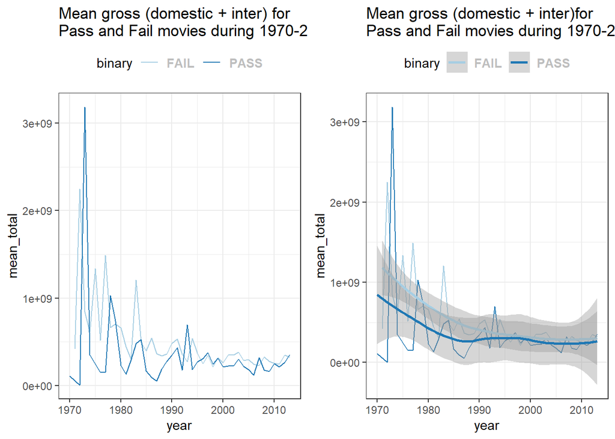

```r
grid.arrange(p2, p5,  ncol = 2)
```

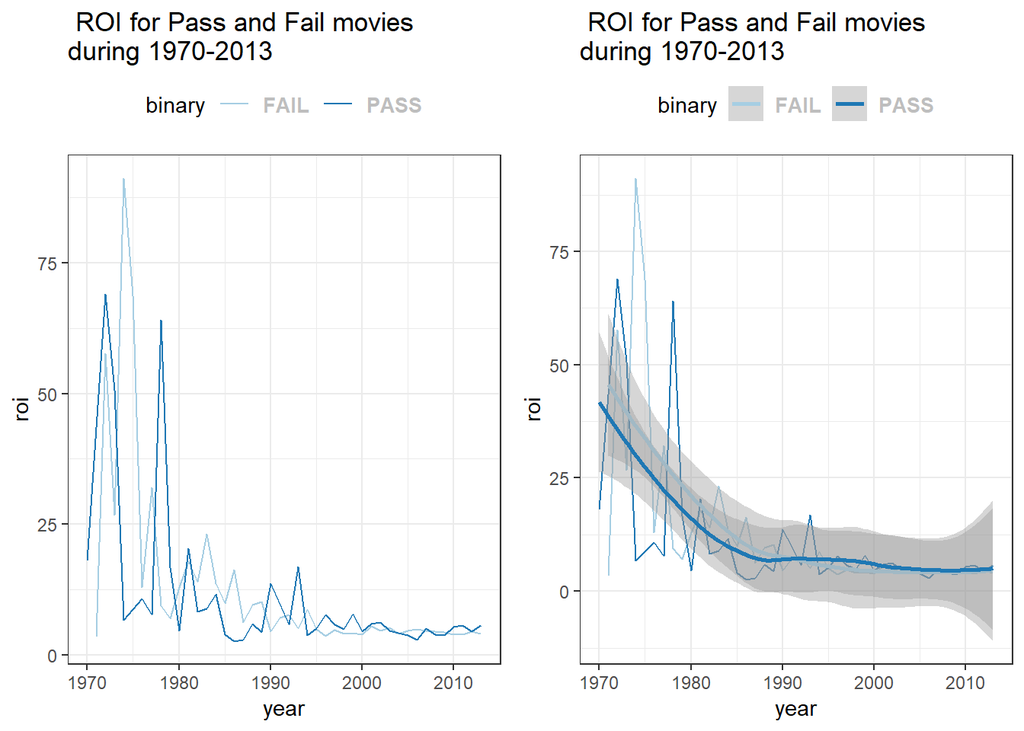

```r
grid.arrange(p3, p6,  ncol = 2)
```

```r
mean_gross <-aggregate(budget_year[, 3:7], list(budget_year$binary), mean)
ratio<-mean_gross[1, 2:6]/mean_gross[2, 2:6]

pander(mean_gross)
```

| Group.1 | mean_budget | mean_domgross | mean_intgross | roi | mean_total |
| --- | --- | --- | --- | --- | --- |
| FAIL | 57518108 | 182908325 | 324188845 | 13.06 | 507097170 |
| PASS | 40758910 | 121494068 | 229112058 | 11.08 | 350606126 |

```r
#ratio FAIL to PASS
pander(ratio)
```

| mean_budget | mean_domgross | mean_intgross | roi | mean_total |
| --- | --- | --- | --- | --- |
| 1.411 | 1.505 | 1.415 | 1.179 | 1.446 |

2. Propose a model that will predict whether a movie passes or fails (the binary variable) based on whatever other variables in the data are available that you think are useful.

We can start with logistic regression. Check the correlation between the variables:

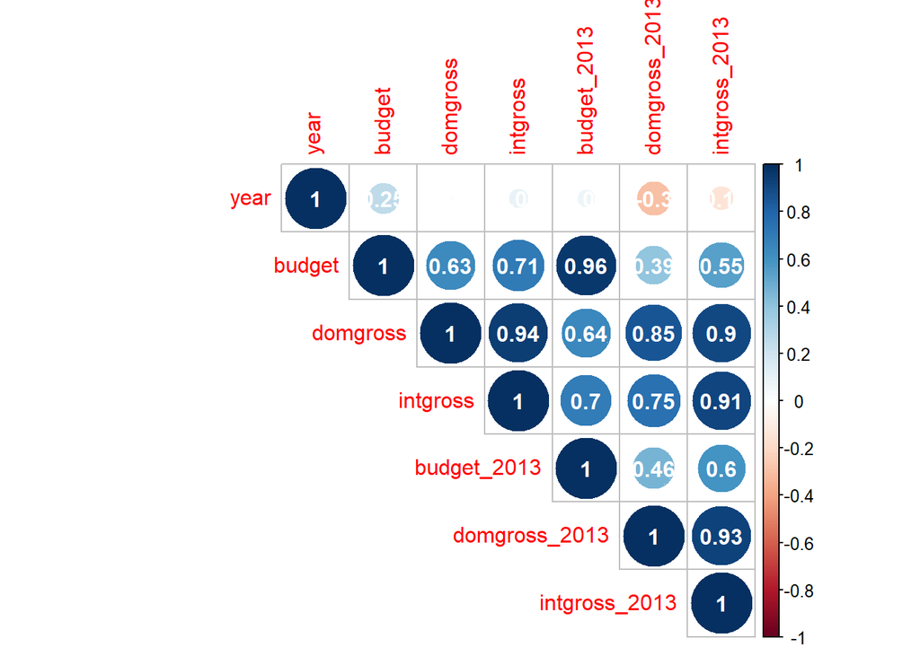

```r
mydata <- bechdel %>%
  dplyr::select_if(is.numeric)
predictors <- colnames(mydata)
bechdel.cor = cor(bechdel[predictors])
corrplot(bechdel.cor, type = 'upper', diag = T, addCoef.col = "white")
```

```r
#list of variables
dput(names(bechdel))
```

```
## c("year", "imdb", "budget", "domgross", "intgross", "code", "budget_2013",
## "domgross_2013", "intgross_2013", "binary", "decade")
```

```r
#bechdel[predictors] <- scale(bechdel[predictors])

#add binary output
bechdel$output <- ifelse(bechdel$binary=="PASS", 1, 0)
```

```r
glm.fit1 <- glm(output ~ year + budget + domgross + intgross +budget_2013 + domgross_2013 + intgross_2013, data = bechdel, family = "binomial")
#testing the importance of predictors
dropterm(glm.fit1, test = "F")
```

```
## Single term deletions
##
## Model:
## output ~ year + budget + domgross + intgross + budget_2013 +
##     domgross_2013 + intgross_2013
##               Df Deviance    AIC F value     Pr(F)
## <none>             1977.3 1993.3
## year           1   1977.5 1991.5  0.1696 0.6805187
## budget         1   1978.8 1992.8  1.1357 0.2867331
## domgross       1   1991.0 2005.0 10.2599 0.0013885 **
## intgross       1   1985.8 1999.8  6.3715 0.0117008 *
## budget_2013    1   1982.6 1996.6  3.9360 0.0474488 *
## domgross_2013  1   1993.4 2007.4 11.9953 0.0005486 ***
## intgross_2013  1   1987.4 2001.4  7.5775 0.0059826 **
## ---
## Signif. codes:  0 '***' 0.001 '**' 0.01 '*' 0.05 '.' 0.1 ' ' 1
```

```r
# drop year and budget
glm.fit2 <- glm(output ~  domgross + intgross +budget_2013 + domgross_2013 + intgross_2013, data = bechdel, family = "binomial")
summary(glm.fit2)
```

```
##
## Call:
## glm(formula = output ~ domgross + intgross + budget_2013 + domgross_2013 +
##     intgross_2013, family = "binomial", data = bechdel)
##
## Deviance Residuals:
##     Min       1Q   Median       3Q      Max
## -1.3896  -1.1265  -0.8264   1.1708   2.5484
##
## Coefficients:
##                 Estimate Std. Error z value Pr(>|z|)
## (Intercept)    1.543e-01  8.204e-02   1.881 0.059933 .
## domgross       2.145e-08  6.382e-09   3.361 0.000778 ***
## intgross      -7.742e-09  3.052e-09  -2.537 0.011194 *
## budget_2013   -7.457e-09  1.449e-09  -5.147 2.65e-07 ***
## domgross_2013 -1.725e-08  4.843e-09  -3.561 0.000369 ***
## intgross_2013  6.799e-09  2.418e-09   2.811 0.004933 **
## ---
## Signif. codes:  0 '***' 0.001 '**' 0.01 '*' 0.05 '.' 0.1 ' ' 1
##
## (Dispersion parameter for binomial family taken to be 1)
##
##     Null deviance: 2040.8  on 1483  degrees of freedom
## Residual deviance: 1978.9  on 1478  degrees of freedom
## AIC: 1990.9
##
## Number of Fisher Scoring iterations: 5
```

```r
# checking VIF
vif(glm.fit2)
```

```
##      domgross      intgross   budget_2013 domgross_2013 intgross_2013
##     88.835074    137.311486      1.975563     92.539381    138.585171
```

VIF suggests presence of very strong multicollinearity, so we have to deal with it. Examine the behaviour of predictors:

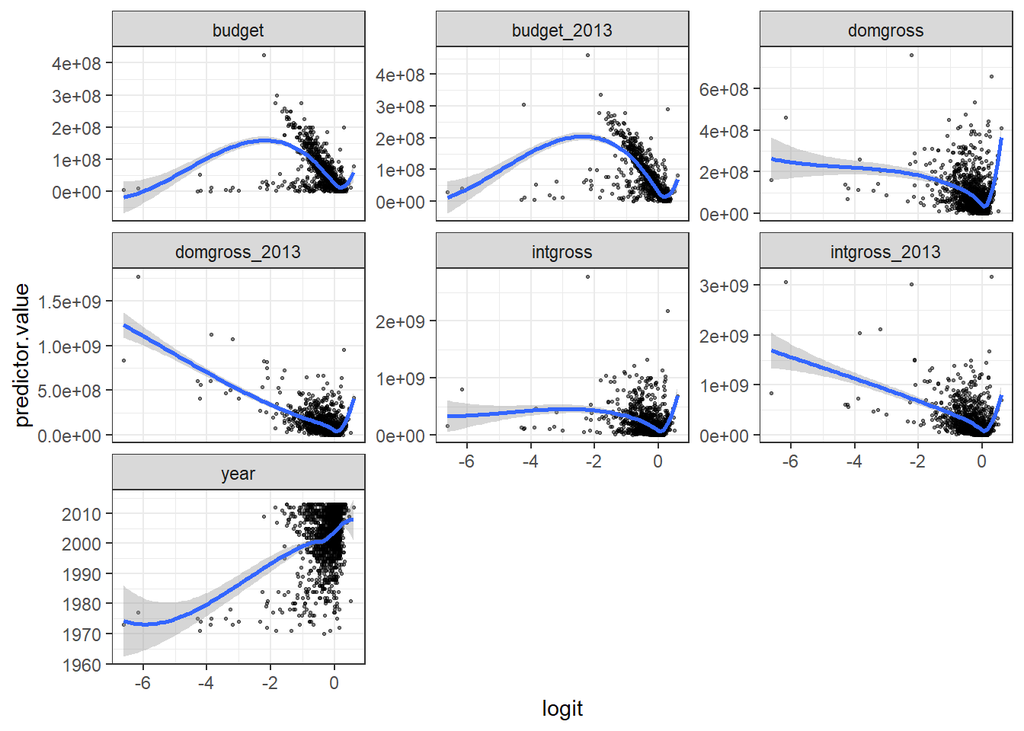

```r
probabilities <- predict(glm.fit2, type = "response")
mydata <- mydata %>%
  mutate(logit = log(probabilities/(1-probabilities))) %>%
  tidyr::gather(key = "predictors", value = "predictor.value", -logit)

ggplot(mydata, aes(logit, predictor.value))+
  geom_point(size = 0.5, alpha = 0.5) +
  geom_smooth(method = "loess") +
  theme_bw() +
  facet_wrap(~predictors, scales = "free_y")
```

```r
test <- read.csv("test.csv")
test<-test[complete.cases(test), ]
str(test)
```

```
## 'data.frame':    292 obs. of  9 variables:
##  $ year         : int  2013 2013 2013 2013 2013 2013 2013 2013 2013 2013 ...
##  $ imdb         : Factor w/ 294 levels "tt0067065","tt0071360",..: 268 195 238 253 274 290 278 262 277 285 ...
##  $ budget       : int  50000000 40000000 70000000 195000000 28000000 2000000 75000000 120000000 190000000 35000000 ...
##  $ domgross     : num  19452138 57012977 25213103 65187603 28795985 ...
##  $ intgross     : num  5.59e+07 6.65e+07 1.04e+08 1.97e+08 6.08e+07 ...
##  $ code         : Factor w/ 63 levels "1971FAIL","1974FAIL",..: 63 63 62 62 63 63 62 62 62 63 ...
##  $ budget_2013  : int  50000000 40000000 70000000 195000000 28000000 2000000 75000000 120000000 190000000 35000000 ...
##  $ domgross_2013: int  19452138 57012977 25213103 65187603 28795985 8008161 117723989 89107235 101802906 17616641 ...
##  $ intgross_2013: int  55940671 66454811 103813103 197387603 60839197 9408161 351723989 287537983 411002906 46346651 ...
```

```r
glm.probs <- predict(glm.fit2,
                    newdata = test,
                    type = "response")

glm.pred <- ifelse(glm.probs > 0.5, 1, 0)
test$prediction <- as.factor(glm.pred)
```

```r
# Model performance

test$binary_correct <- substr(test$code, 5,8)

test$correct <- as.factor(ifelse(test$binary_correct=="PASS", 1, 0))
accuracy <- table(test$prediction, test$correct)
sum(diag(accuracy))/sum(accuracy)
```

```
## [1] 0.6130137
```

```r
confusionMatrix(test$prediction, test$correct)
```

```
## Confusion Matrix and Statistics
##
##           Reference
## Prediction   0   1
##          0 119  70
##          1  43  60
##
##                Accuracy : 0.613
##                  95% CI : (0.5545, 0.6692)
##     No Information Rate : 0.5548
##     P-Value [Acc > NIR] : 0.02556
##
##                   Kappa : 0.2002
##  Mcnemar's Test P-Value : 0.01445
##
##             Sensitivity : 0.7346
##             Specificity : 0.4615
##          Pos Pred Value : 0.6296
##          Neg Pred Value : 0.5825
##              Prevalence : 0.5548
##          Detection Rate : 0.4075
##    Detection Prevalence : 0.6473
##       Balanced Accuracy : 0.5981
##
##        'Positive' Class : 0
##
```

not so exciting results…

```r
#Simply save your predictions in a csv file with the variable 'mdb' to indicate the
#movie and your classification of 0 or 1.

test_prediction <- test %>% dplyr::select(imdb, prediction) %>% rename(mdb=imdb)
write.csv(test_prediction, "test_prediction.csv")
```